# Week 5 Analytical Assigment

M. Onimus

04/6/2020

# R Set up

Before getting started, I have loaded in a few packages to help us with the analysis.

- `tidyverse`: A collection of r packages used to make data import, manipulation, and analysis easier.
- `here`: A package that makes it easier to navigate around the folder structure.
- `haven`: A package with a set of functions for reading in SAS files.
- `rstatix`: A package to quickly calculate ttest between variables
- `kableExtra`: A package for printing pretty tables to html.
- `table1`: A package that allows for creation of table 1’s with relative ease
- `MatchIt`: A package used to create PSM

# From the Assignment

## Introduction

For the assignment you will use the data set diff_in_diff_hwk, which has the following variables:

- subject - Unique observation identifier
- treatment - 1=recieved the treatment; 0=did not recieve the treatment
- time - 1=time 1 (pre-period, or baseline); 2=time 2 (post-period, or follow-up)
- SEX - 1=patient was male; 0=patient was female
- AGE - age in years
- num_chron: total number of chonic conditions
- urban_rural: 1=live in an urban area; 0=live in or non-urban (rural, or suburban) area
- unemp_rate: unemployment rate in the subject’s zip code
- med_hh_income: median household income in the subject’s zip code
- disease_burden: general score of disease states at baseline - higher scores indicate higher illness burden
- IP_visits_pmpm: number of inpatient admissions
- IP_cost_PMPM: medical costs associated with inpatient admissions
- IP_cost_PMPM1: medical costs associated with inpatient admissions +$1.00 for cost analyses using log link and gamma distribution.
- IP_visit_flag; 1=had at least 1 inpatient (IP) admission; 0=did not have an IP admission
- total_cost_pmpm: total medical costs
- total_cost_PMPM1: total medical costs associated with ER visits +$1.00 for cost analyses using log link and gamma distribution.

Note: PMPM refers to Per Member Per Month - an aggregate of the cost (or utilization) over a 12-month period divided by 12 to give an average per month for each person. In some contexts, observations for some patients may be observed over differing lengths of time so computing a measure on a per-month basis allow comparisons to be made between patients with different lengths of observation.

# Assignment Start

## Read the data in

In order to read the data into R, we will need to use the `haven` package.

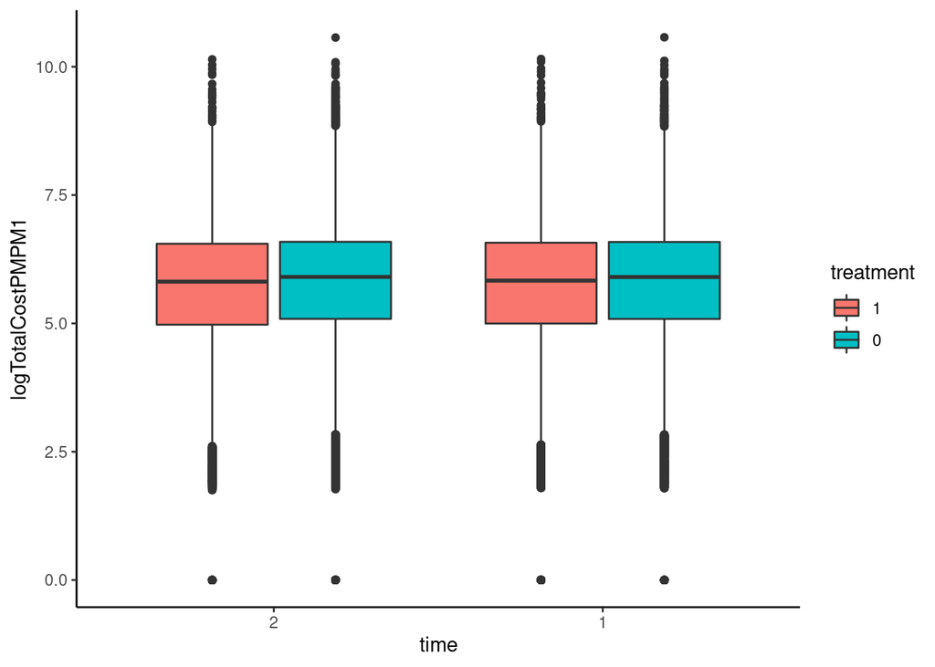

```r
multi <- read_sas(here("data/diff_in_diff_hwk.sas7bdat")) %>%
  mutate(treatment = as.factor(treatment),
         treatment = relevel(treatment, ref = '1'),
         time = as.factor(time),
         time = relevel(time, ref = '2'),
         logTotalCostPMPM1 = log(total_cost_pmpm1)
         )


ggplot(multi, aes(x = time, y= logTotalCostPMPM1, fill = treatment)) +
  geom_boxplot() +
  theme_classic()
```

This data set contains 200000 rows with 17 variables, as described in the data overview.

## Questions 1-4

Run the following generalized linear model using PROC GENMOD

```r
glm1 <- glm(total_cost_pmpm1 ~ time + treatment + time*treatment,
            family = Gamma(link = "log"), data = multi)

glm1
```

```
##
## Call:  glm(formula = total_cost_pmpm1 ~ time + treatment + time * treatment,
##     family = Gamma(link = "log"), data = multi)
##
## Coefficients:
##      (Intercept)             time1        treatment0  time1:treatment0
##          6.28424           0.02048           0.04905          -0.02298
##
## Degrees of Freedom: 199999 Total (i.e. Null);  199996 Residual
## Null Deviance:       244000
## Residual Deviance: 243900    AIC: 2930000
```

```r
summary(glm1)
```

```
##
## Call:
## glm(formula = total_cost_pmpm1 ~ time + treatment + time * treatment,
##     family = Gamma(link = "log"), data = multi)
##
## Deviance Residuals:
##     Min       1Q   Median       3Q      Max
## -3.2665  -1.0459  -0.4112   0.2714  11.3453
##
## Coefficients:
##                   Estimate Std. Error t value Pr(>|t|)
## (Intercept)       6.284242   0.007156 878.217  < 2e-16 ***
## time1             0.020479   0.010120   2.024   0.0430 *
## treatment0        0.049052   0.008790   5.581  2.4e-08 ***
## time1:treatment0 -0.022981   0.012431  -1.849   0.0645 .
## ---
## Signif. codes:  0 '***' 0.001 '**' 0.01 '*' 0.05 '.' 0.1 ' ' 1
##
## (Dispersion parameter for Gamma family taken to be 1.726899)
##
##     Null deviance: 243979  on 199999  degrees of freedom
## Residual deviance: 243910  on 199996  degrees of freedom
## AIC: 2930234
##
## Number of Fisher Scoring iterations: 6
```

```r
#treatment term
mdscore::wald.test(glm1, terms = 3)
```

```
## $W
## [1] 51.20549
##
## $pvalue
## [1] 8.318578e-13
##
## attr(,"class")
## [1] "wald.test"
```

```r
# interaction term
mdscore::wald.test(glm1, terms = 4)
```

```
## $W
## [1] 5.619689
##
## $pvalue
## [1] 0.0177598
##
## attr(,"class")
## [1] "wald.test"
```

```r
meansTreatment <- lsmeans::lsmeans(glm1, pairwise ~ "treatment")
```

```
## NOTE: Results may be misleading due to involvement in interactions
```

```r
meansTreatment
```

```
## $lsmeans
##  treatment lsmean       SE  df asymp.LCL asymp.UCL
##  1          6.294 0.005060 Inf     6.285     6.304
##  0          6.332 0.003609 Inf     6.325     6.339
##
## Results are averaged over the levels of: time
## Results are given on the log (not the response) scale.
## Confidence level used: 0.95
##
## $contrasts
##  contrast estimate      SE  df z.ratio p.value
##  1 - 0     -0.0376 0.00622 Inf -6.043  <.0001
##
## Results are averaged over the levels of: time
## Results are given on the log (not the response) scale.
```

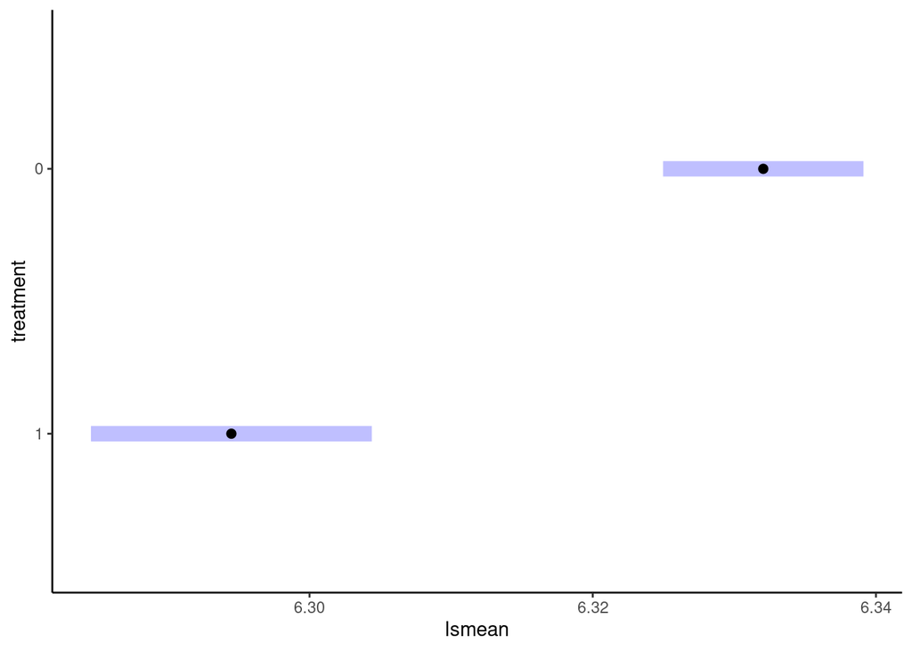

```r
plot(meansTreatment) + theme_classic()
```

```r
meansTime <- lsmeans::lsmeans(glm1, pairwise ~ "time")
```

```
## NOTE: Results may be misleading due to involvement in interactions
```

```r
meansTime
```

```
## $lsmeans
##  time lsmean       SE  df asymp.LCL asymp.UCL
##  2     6.309 0.004395 Inf     6.300     6.317
##  1     6.318 0.004395 Inf     6.309     6.326
##
## Results are averaged over the levels of: treatment
## Results are given on the log (not the response) scale.
## Confidence level used: 0.95
##
## $contrasts
##  contrast estimate      SE  df z.ratio p.value
##  2 - 1    -0.00899 0.00622 Inf -1.446  0.1481
##
## Results are averaged over the levels of: treatment
## Results are given on the log (not the response) scale.
```

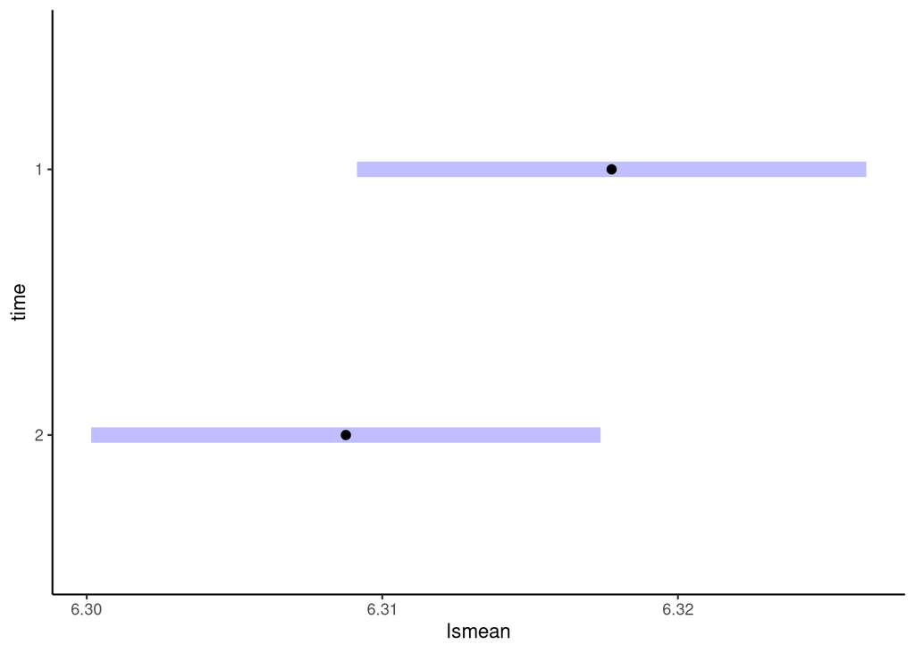

```r
plot(meansTime) + theme_classic()
```

```r
meansTreatmentTime <- lsmeans::lsmeans(glm1, pairwise ~ "time:treatment")

meansTreatmentTime
```

```
## $lsmeans
##  time treatment lsmean       SE  df asymp.LCL asymp.UCL
##  2    1          6.284 0.007156 Inf     6.270     6.298
##  1    1          6.305 0.007156 Inf     6.291     6.319
##  2    0          6.333 0.005105 Inf     6.323     6.343
##  1    0          6.331 0.005105 Inf     6.321     6.341
##
## Results are given on the log (not the response) scale.
## Confidence level used: 0.95
##
## $contrasts
##  contrast  estimate      SE  df z.ratio p.value
##  2 1 - 1 1  -0.0205 0.01012 Inf -2.024  0.1792
##  2 1 - 2 0  -0.0491 0.00879 Inf -5.581  <.0001
##  2 1 - 1 0  -0.0465 0.00879 Inf -5.296  <.0001
##  1 1 - 2 0  -0.0286 0.00879 Inf -3.251  0.0063
##  1 1 - 1 0  -0.0261 0.00879 Inf -2.966  0.0160
##  2 0 - 1 0   0.0025 0.00722 Inf  0.347  0.9857
##
## Results are given on the log (not the response) scale.
## P value adjustment: tukey method for comparing a family of 4 estimates
```

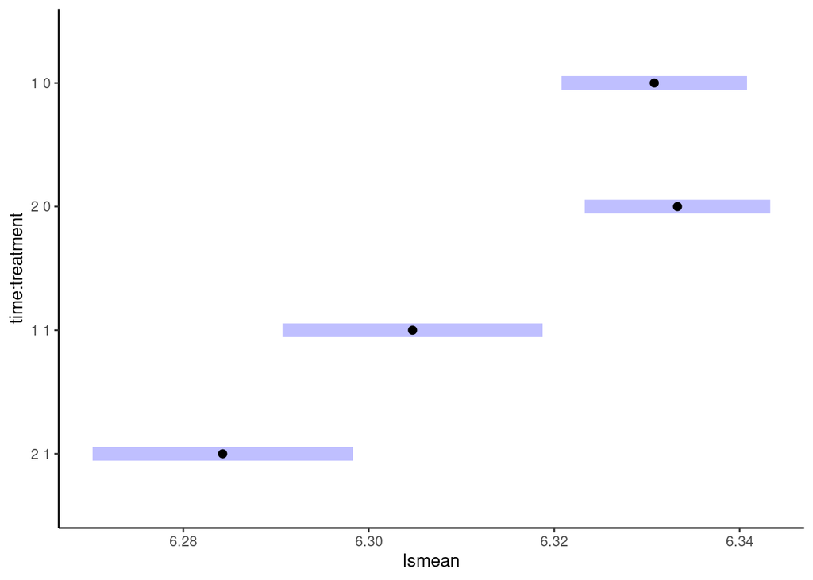

```r
plot(meansTreatmentTime) + theme_classic()
```

## Questions 5-6

Run the following code that uses an identity link and normal distribution. Remember from the lecture that medical costs do not conform to a normal distribution.

```r
glm2 <- glm(total_cost_pmpm1 ~ time + treatment + time*treatment,
            family = gaussian(link = "identity"), data = multi)

glm2
```

```
##
## Call:  glm(formula = total_cost_pmpm1 ~ time + treatment + time * treatment,
##     family = gaussian(link = "identity"), data = multi)
##
## Coefficients:
##      (Intercept)             time1        treatment0  time1:treatment0
##           536.06             11.09             26.95            -12.50
##
## Degrees of Freedom: 199999 Total (i.e. Null);  199996 Residual
## Null Deviance:       1.065e+11
## Residual Deviance: 1.065e+11     AIC: 3205000
```

```r
summary(glm2)
```

```
##
## Call:
## glm(formula = total_cost_pmpm1 ~ time + treatment + time * treatment,
##     family = gaussian(link = "identity"), data = multi)
##
## Deviance Residuals:
##    Min      1Q  Median      3Q     Max
##   -562    -398    -198     164   38526
##
## Coefficients:
##                  Estimate Std. Error t value Pr(>|t|)
## (Intercept)       536.058      3.974 134.896  < 2e-16 ***
## time1              11.091      5.620   1.974   0.0484 *
## treatment0         26.950      4.881   5.521 3.37e-08 ***
## time1:treatment0  -12.498      6.903  -1.810   0.0702 .
## ---
## Signif. codes:  0 '***' 0.001 '**' 0.01 '*' 0.05 '.' 0.1 ' ' 1
##
## (Dispersion parameter for gaussian family taken to be 532587.1)
##
##     Null deviance: 1.0654e+11  on 199999  degrees of freedom
## Residual deviance: 1.0652e+11  on 199996  degrees of freedom
## AIC: 3204682
##
## Number of Fisher Scoring iterations: 2
```

```r
#treatment term
mdscore::wald.test(glm2, terms = 3)
```

```
## $W
## [1] 30.48209
##
## $pvalue
## [1] 3.369638e-08
##
## attr(,"class")
## [1] "wald.test"
```

```r
# interaction term
mdscore::wald.test(glm2, terms = 4)
```

```
## $W
## [1] 3.277706
##
## $pvalue
## [1] 0.070227
##
## attr(,"class")
## [1] "wald.test"
```

```r
meansTreatment2 <- lsmeans::lsmeans(glm2, pairwise ~ "treatment")
```

```
## NOTE: Results may be misleading due to involvement in interactions
```

```r
meansTreatment2
```

```
## $lsmeans
##  treatment lsmean   SE  df asymp.LCL asymp.UCL
##  1            542 2.81 Inf       536       547
##  0            562 2.00 Inf       558       566
##
## Results are averaged over the levels of: time
## Confidence level used: 0.95
##
## $contrasts
##  contrast estimate   SE  df z.ratio p.value
##  1 - 0       -20.7 3.45 Inf -5.997  <.0001
##
## Results are averaged over the levels of: time
```

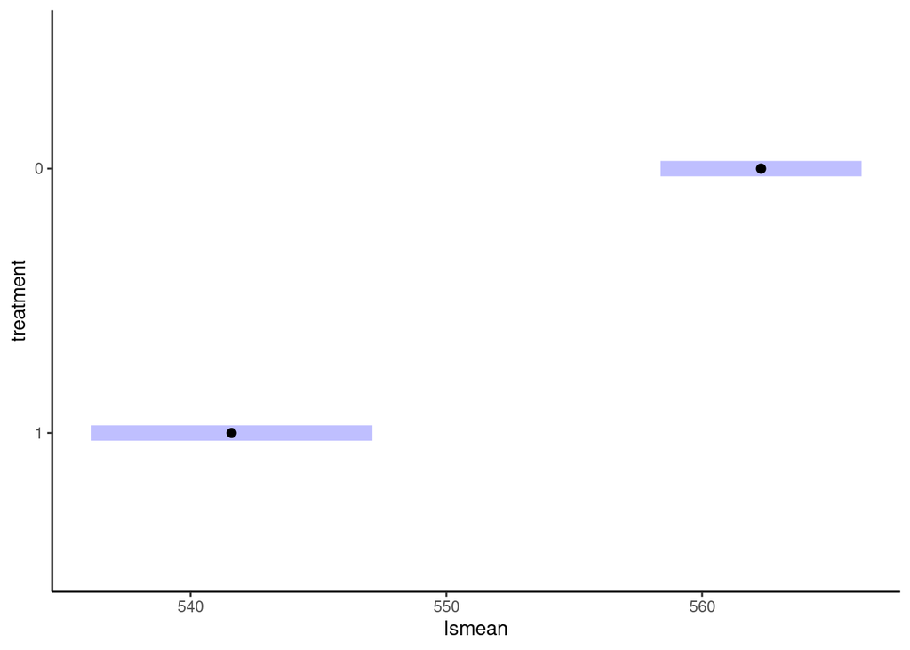

```r
plot(meansTreatment2) + theme_classic()
```

```r
meansTime2 <- lsmeans::lsmeans(glm2, pairwise ~ "time")
```

```
## NOTE: Results may be misleading due to involvement in interactions
```

```r
meansTime2
```

```
## $lsmeans
##  time lsmean   SE  df asymp.LCL asymp.UCL
##  2       550 2.44 Inf       545       554
##  1       554 2.44 Inf       550       559
##
## Results are averaged over the levels of: treatment
## Confidence level used: 0.95
##
## $contrasts
##  contrast estimate   SE  df z.ratio p.value
##  2 - 1       -4.84 3.45 Inf -1.403  0.1607
##
## Results are averaged over the levels of: treatment
```

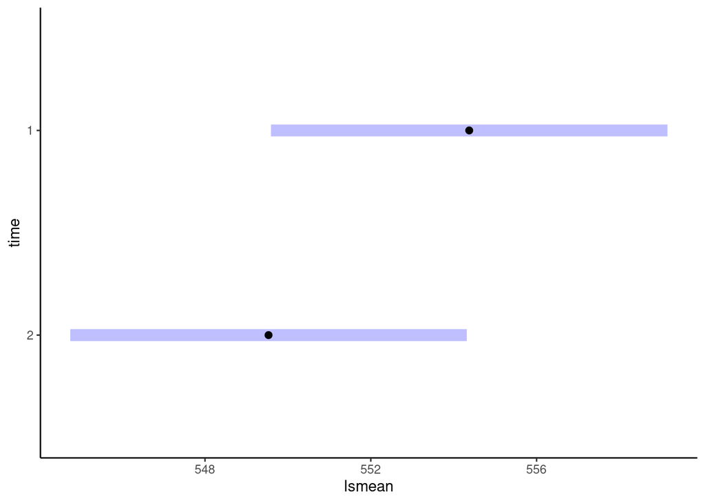

```r
plot(meansTime2) + theme_classic()
```

```r
meansTreatmentTime2 <- lsmeans::lsmeans(glm2, pairwise ~ "time:treatment")

meansTreatmentTime2
```

```
## $lsmeans
##  time treatment lsmean   SE  df asymp.LCL asymp.UCL
##  2    1            536 3.97 Inf       528       544
##  1    1            547 3.97 Inf       539       555
##  2    0            563 2.83 Inf       557       569
##  1    0            562 2.83 Inf       556       567
##
## Confidence level used: 0.95
##
## $contrasts
##  contrast  estimate   SE  df z.ratio p.value
##  2 1 - 1 1   -11.09 5.62 Inf -1.974  0.1980
##  2 1 - 2 0   -26.95 4.88 Inf -5.521  <.0001
##  2 1 - 1 0   -25.54 4.88 Inf -5.233  <.0001
##  1 1 - 2 0   -15.86 4.88 Inf -3.249  0.0064
##  1 1 - 1 0   -14.45 4.88 Inf -2.961  0.0162
##  2 0 - 1 0     1.41 4.01 Inf  0.351  0.9852
##
## P value adjustment: tukey method for comparing a family of 4 estimates
```

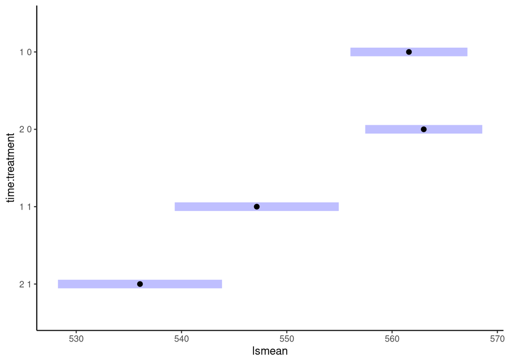

```r
plot(meansTreatmentTime2) + theme_classic()
```

Describe how the results and the interpretation of the effect of the treatment on costs changed. (This analysis is meant to demonstrate how using the inappropriate methods can lead to potentially misleading results)